# HW 22

## James Camacho

### Runge-Kutta Method

We have the one-step implicit method

$$U^* = U^n + \frac{k}{2}f\left(U^*, t_n+\frac{k}{2}\right),$$$$U^{n+1} = U^n + kf\left(U^*, t_n + \frac{k}{2}\right).$$

This is equivalent to the following two-step method:

$$V^{n+2} - V^{n} = 2hf(V^{n+1}, t_{n+1}).$$

where $2h = k$.

### (1) - Order of Accuracy

Notice it is equivalent to a backwards Euler followed by a forwards Euler. We would expect the two to cancel out to give one extra degree of accuracy. This is what we find:

We have $\alpha = (-1, 0, 1); \beta = (0, 2, 0)$. It's consistent as $\sum_{j=0}^2 \alpha_j = 0.$ We also have

$$\sum_{j=0}^2 j^1\alpha_j = 2 = 1\cdot \sum_{j=0}^2 j^0\beta_j,$$$$\sum_{j=0}^2 j^2\alpha_j = 4 = 2\cdot \sum_{j=0}^2 j^1\beta_j,$$$$\sum_{j=0}^2 j^3\alpha_j = 8 \ne 6 = 3\cdot \sum_{j=0}^3 j^2\beta_j.$$

So it is second-order accurate.

### (2) - Stability Region

We use the test function $u' = \lambda u.$ Let $z = k\lambda.$ Then

$$U^* = U^{n} + \frac{z}{2}U^*\Longleftrightarrow U^* = \frac{2}{2-z}U^{n}$$$$U^{n+1} = U^{n} + zU^* = \frac{2+z}{2-z}U^n.$$

(Notice that the first few terms of it's Taylor series are $1+z+\frac{z^2}{2}+\frac{z^3}{4}$ so it agrees with $e^z$ up to order $2$, another way to see it's second-order accurate.)

It's stable whenever $|2+z| \le |2-z|$ i.e. the LHS of the complex plane.

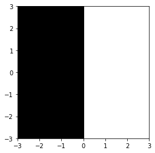

```python
import matplotlib.pyplot as plt

c = plt.Rectangle((-3, -3), 3, 6, color='black')
plt.gca().add_patch(c)
plt.xlim(-3, 3)
plt.ylim(-3, 3)
plt.gca().set_aspect('equal')
plt.show();
```

### (3) - A/L-stable?

By definition it is A-stable, as the stability region is the entire left hand of the complex plane. It is not L-stable as

$$\lim_{z\to\infty} \left|\frac{2+z}{2-z}\right| = 1\ne 0.$$